# Exploratory analysis: New Henri meeting typology

## New typology

This new typology has 4 categories with a minimum of 4 items per category (which is good). We’ll use shorter labels for the data analysis below. In the tables below, the items are grouped under the column called “henriLab”, and the following labels are used for the four groups:

- Core = Core functions of the state
- Fundamentals = State fundamental elements
- Organisation = State organisation
- Protection = Protection of Individuals

One can quibble about the specific label used above, but this is not an analytical issue. More importantly, the items seem to group quite naturally. I have a minor point regarding the “Protection of Individuals” category (see section at the end), but this does not make much of a difference to the end result.

| Item | henriLab | Question |
| --- | --- | --- |
| 48 | Core | Are referendums related to international law obligations prohibited? |
| 54 | Core | Are referendums on state finances (budget, taxes, or other financial obligations) prohibited? |
| 55 | Core | Are referendums on issues related to national security (military, police, secret services) prohibited? |
| 56 | Core | Are referendums on emergency powers (declaration of war, state of emergency etc) or urgent matters prohibited? |
| 50 | Fundamentals | Are referendums on state structure or form of government prohibited? |
| 51 | Fundamentals | Are referendums on state symbols prohibited? |
| 52 | Fundamentals | Are referendums on the official language prohibited? |
| 53 | Fundamentals | Are referendums on territorial issues or territorial integrity prohibited? |
| 60 | Organisation | Are referendums on the rules of elections and referendums prohibited? |
| 61 | Organisation | Are referendums on the election or appointment of state officials or civil service laws prohibited? |
| 62 | Organisation | Are referendums on legislative competences prohibited? |
| 63 | Organisation | Are referendums on executive competences prohibited? |
| 64 | Organisation | Are referendums on issues related to the judiciary (competences, independence etc) prohibited? |
| 65 | Organisation | Are referendums on issues related to local governance prohibited? |
| 49 | Protections | Are referendums related to fundamental rights and freedoms prohibited? |
| 57 | Protections | Are referendums on pardon and amnesty prohibited? |
| 58 | Protections | Are referendums on naturalisation issues prohibited? |
| 59 | Protections | Are referendums on minorities or minority rights prohibited? |

# Graphing the Dimensions of Substantive prohoibitions

As we look at each of the four dimensions below, we should be thinking whether the items shown in the table hang together to measure the putative construct.

| Item | henriLab | Question |
| --- | --- | --- |
| 60 | Organisation | Are referendums on the rules of elections and referendums prohibited? |
| 61 | Organisation | Are referendums on the election or appointment of state officials or civil service laws prohibited? |
| 62 | Organisation | Are referendums on legislative competences prohibited? |
| 63 | Organisation | Are referendums on executive competences prohibited? |
| 64 | Organisation | Are referendums on issues related to the judiciary (competences, independence etc) prohibited? |
| 65 | Organisation | Are referendums on issues related to local governance prohibited? |

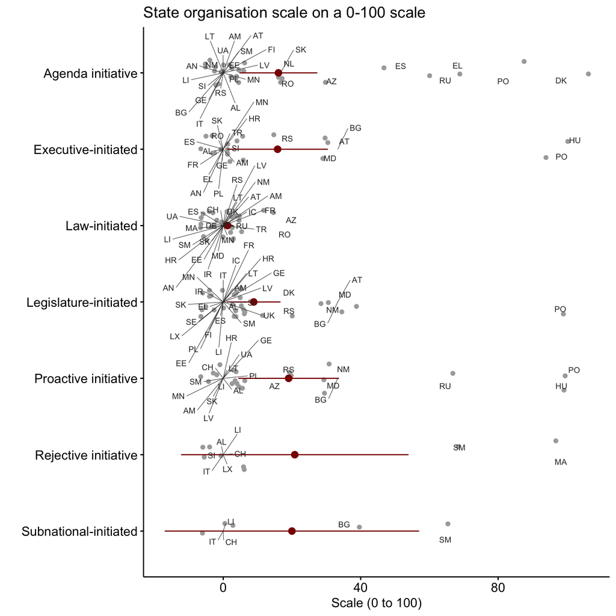

# Core state functions

| Item | henriLab | Question |
| --- | --- | --- |
| 48 | Core | Are referendums related to international law obligations prohibited? |
| 54 | Core | Are referendums on state finances (budget, taxes, or other financial obligations) prohibited? |
| 55 | Core | Are referendums on issues related to national security (military, police, secret services) prohibited? |
| 56 | Core | Are referendums on emergency powers (declaration of war, state of emergency etc) or urgent matters prohibited? |

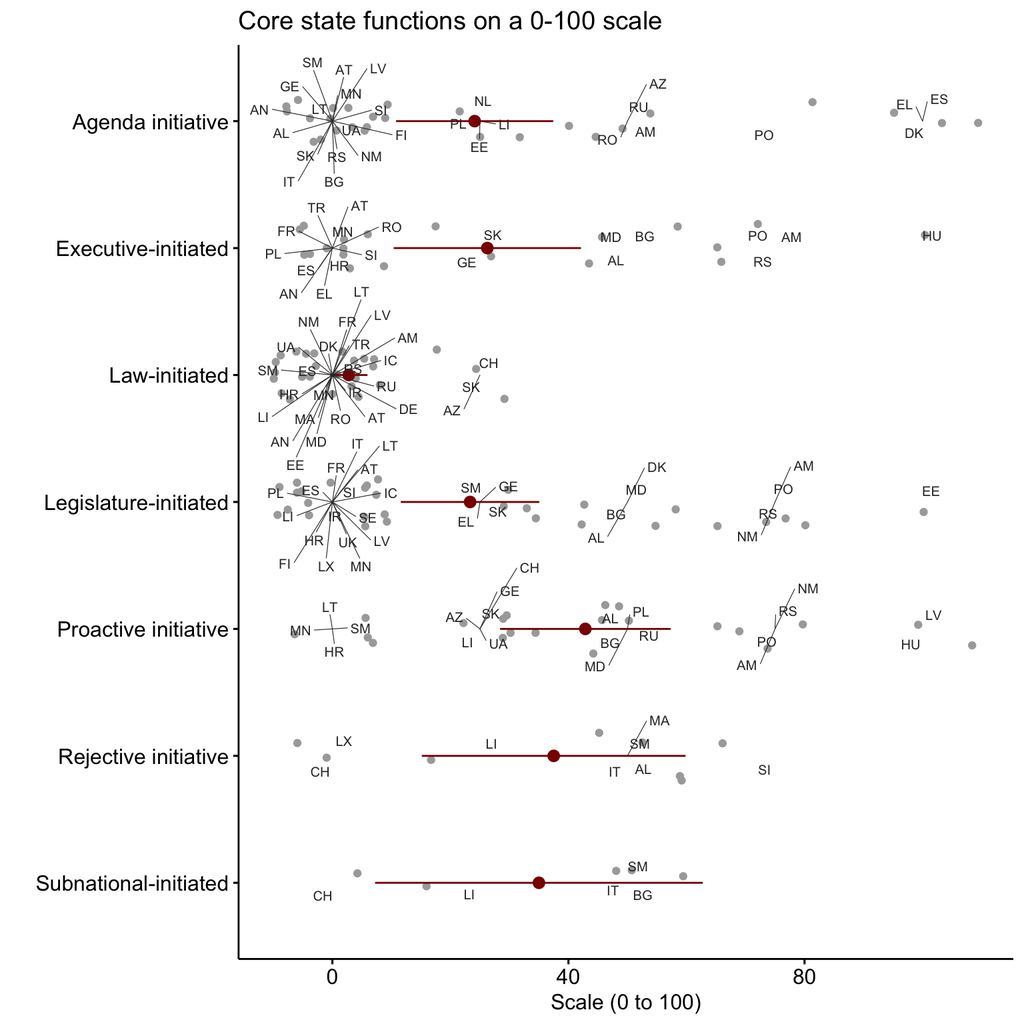

# State fundamentals

#### State fundamentals (4 items)

| Item | henriLab | Question |
| --- | --- | --- |
| 50 | Fundamentals | Are referendums on state structure or form of government prohibited? |
| 51 | Fundamentals | Are referendums on state symbols prohibited? |
| 52 | Fundamentals | Are referendums on the official language prohibited? |
| 53 | Fundamentals | Are referendums on territorial issues or territorial integrity prohibited? |

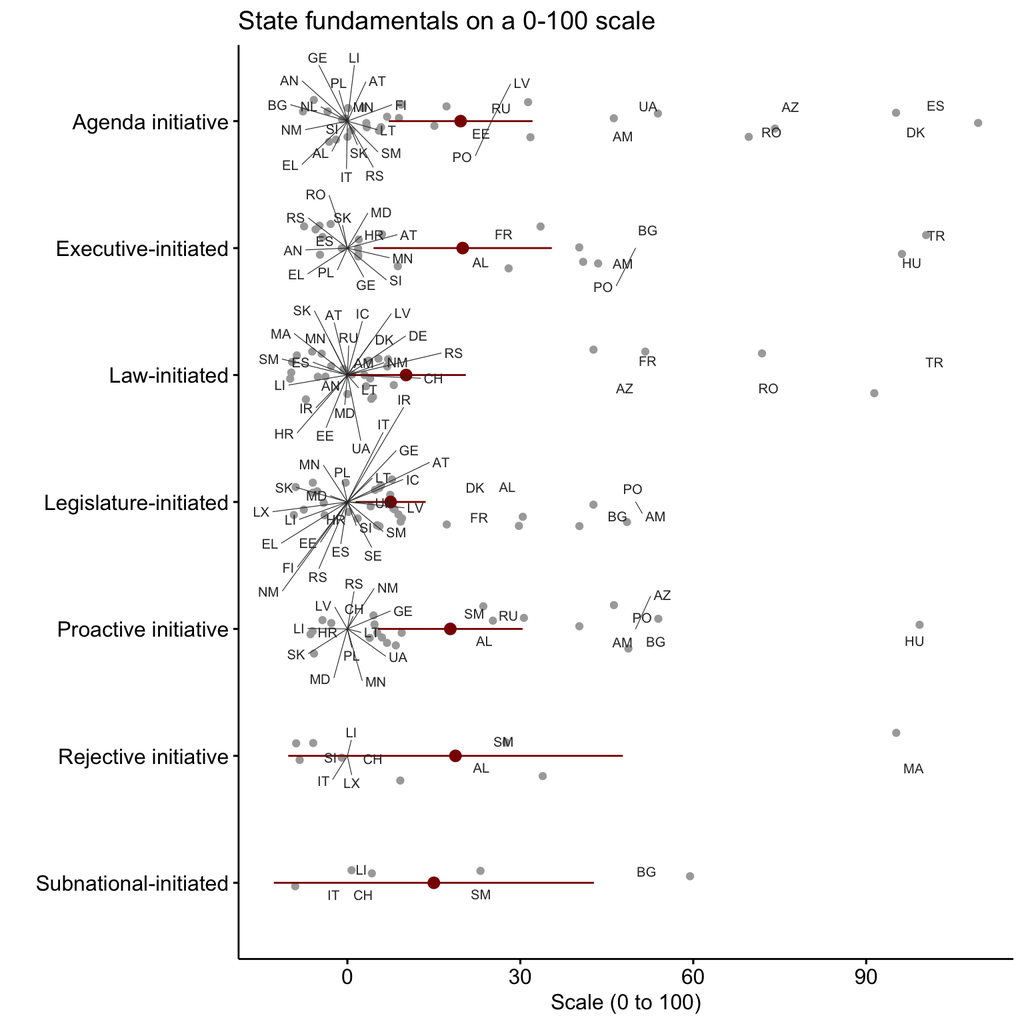

# Protection of individuals

#### Protection of individuals (4 items)

| Item | henriLab | Question |
| --- | --- | --- |
| 49 | Protections | Are referendums related to fundamental rights and freedoms prohibited? |
| 57 | Protections | Are referendums on pardon and amnesty prohibited? |
| 58 | Protections | Are referendums on naturalisation issues prohibited? |
| 59 | Protections | Are referendums on minorities or minority rights prohibited? |

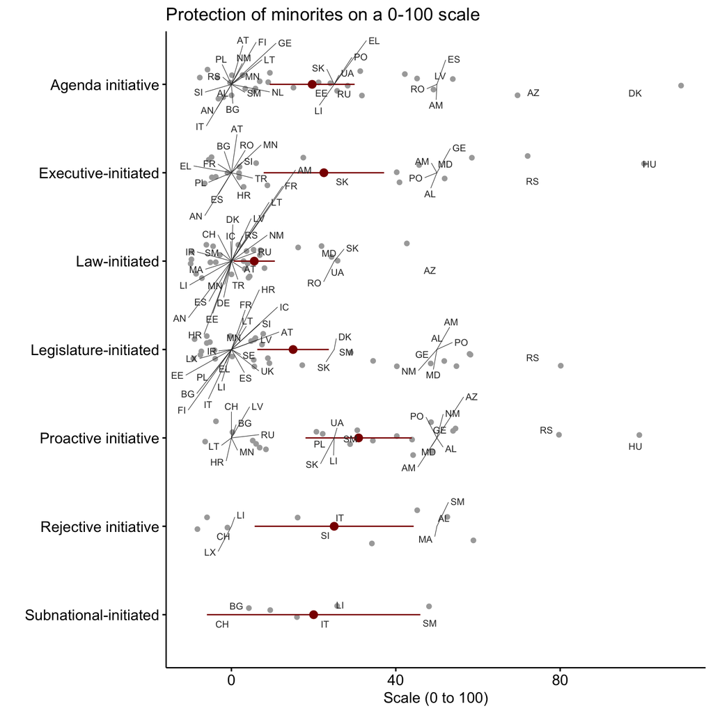

# Analysis of Protection of individual (without Pardons/Amnesties)

The three items below seem more consistent with a more conventional understanding of the concept of protection of individuals, I’m not sure how the inclusion of the Pardons/Amnesties item fits in this dimension.

The question to pose is: whether a country that prohibits referencums on Pardons/Amenesties is protecting individuals. To me such prohibitions are more about protecting the discretion of the state to act rather than protecting indviduals/minorities.

However, for the actual analysis it doesn’t make much difference to the scores whether we use a 3 or a 4 item version of the concept. It’s more of a conceptual issue.

#### Protection of individuals (3 items)

| Item | henriLab | Question |
| --- | --- | --- |
| 49 | Protections | Are referendums related to fundamental rights and freedoms prohibited? |
| 58 | Protections | Are referendums on naturalisation issues prohibited? |
| 59 | Protections | Are referendums on minorities or minority rights prohibited? |

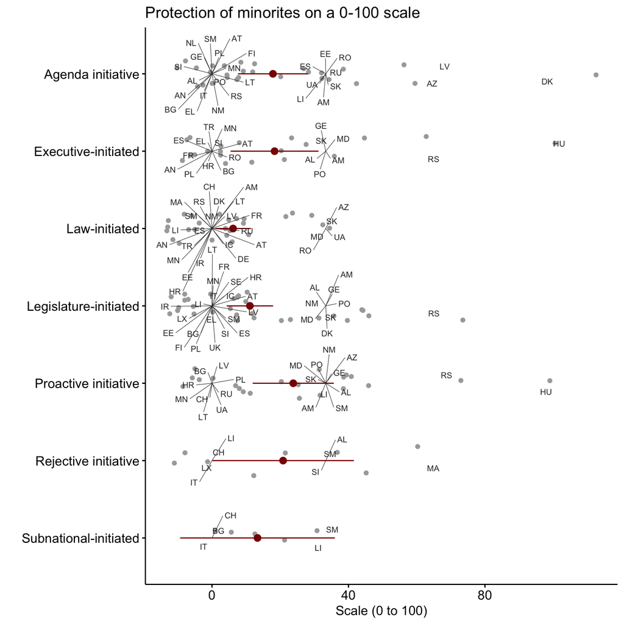

#### In the matrix below we can see the breakdwon by country and instrument for the item on Pardons/Amnesties.

### Matrix of Countries with Pardons/Amnesties prohibitin per Instrument

|  | Agenda initiative | Executive-initiated | Law-initiated | Legislature-initiated | Proactive initiative | Rejective initiative | Subnational-initiated |
| --- | --- | --- | --- | --- | --- | --- | --- |
| Albania |  | Yes |  | Yes | Yes | Yes |  |
| Andorra | No | No |  |  |  |  |  |
| Armenia | Yes | Yes |  | Yes | Yes |  |  |
| Austria |  | No |  | No |  |  |  |
| Azerbaijan | Yes |  | Yes |  | Yes |  |  |
| Bulgaria |  | No |  | No | No |  | No |
| Denmark | Yes |  |  | No |  |  |  |
| Estonia | No |  |  | No |  |  |  |
| France |  | No | No | No |  |  |  |
| Georgia |  | Yes |  | Yes | Yes |  |  |
| Greece | Yes |  |  | No |  |  |  |
| Hungary |  | Yes |  |  | Yes |  |  |
| Iceland |  |  | No |  |  |  |  |
| Italy |  |  |  |  |  | Yes | Yes |
| Latvia | No |  |  |  | No |  |  |
| Liechtenstein | No |  |  |  | No | No | No |
| Luxembourg |  |  |  | No |  | No |  |
| Malta |  |  |  |  |  | No |  |
| Moldova |  | Yes | No | Yes | Yes |  |  |
| Montenegro | No |  |  |  |  |  |  |
| Netherlands | No |  |  |  |  |  |  |
| North Macedonia |  |  |  | Yes | Yes |  |  |
| Poland | No |  |  |  | Yes |  |  |
| Portugal | Yes | Yes |  | Yes | Yes |  |  |
| Romania | Yes |  | No |  |  |  |  |
| Russia | No |  |  |  | No |  |  |
| San Marino |  |  |  | Yes | No | Yes | Yes |
| Serbia |  | Yes |  | Yes | Yes |  |  |
| Slovakia | No | No | No | No | No |  |  |
| Slovenia |  |  |  |  |  | No |  |
| Spain | Yes |  |  |  |  |  |  |
| Switzerland |  |  | No |  | No |  |  |
| Turkey |  | No | No |  |  |  |  |
| Ukraine | No |  | No |  | Yes |  |  |

# Annex I

## Substantive prohibitions that don’t occur per instrument

Below we identify the items/questions that did not elicit a prohobition. That is, we do not empirically find prohibitions for those items in the instruments listed. Not surprisingly, it is the Law-initiated referendum where certain items/questions do not get “Yes” answers (i.e., prohibitions). I guess this raises the question of how relevant it is to focus on substantive prohibitions in the case of the Law-initiated referendum.

Similarly, the Subnational referendum generates non-prohibitions but this is the result of the low number of country cases (5) which provide for this instrument.

| Item | Question |
| --- | --- |
| **Law-initiated** |  |
| 55 | Are referendums on issues related to national security (military, police, secret services) prohibited? |
| 56 | Are referendums on emergency powers (declaration of war, state of emergency etc) or urgent matters prohibited? |
| 58 | Are referendums on naturalisation issues prohibited? |
| 59 | Are referendums on minorities or minority rights prohibited? |
| 60 | Are referendums on the rules of elections and referendums prohibited? |
| 62 | Are referendums on legislative competences prohibited? |
| 63 | Are referendums on executive competences prohibited? |
| 65 | Are referendums on issues related to local governance prohibited? |
| **Legislature-initiated** |  |
| 52 | Are referendums on the official language prohibited? |
| **Rejective initiative** |  |
| 55 | Are referendums on issues related to national security (military, police, secret services) prohibited? |
| 58 | Are referendums on naturalisation issues prohibited? |
| **Subnational-initiated** |  |
| 51 | Are referendums on state symbols prohibited? |
| 52 | Are referendums on the official language prohibited? |
| 55 | Are referendums on issues related to national security (military, police, secret services) prohibited? |
| 58 | Are referendums on naturalisation issues prohibited? |
| 59 | Are referendums on minorities or minority rights prohibited? |
| 60 | Are referendums on the rules of elections and referendums prohibited? |

# Annex II

## Comparing Dimensions

Below we examine the aggregated dimensions. There are several ways to look at these. From the most aggregated level below (basically the average per dimension), through to the most fine-grained, average per dimension grouped by instrument. The latter is the more informative in terms of representing the distribution of the data.

*Note: The scale ranges from 0-100 (useful to keep this in mind because the average scores are always on the low end of the scale)*

## Average dimension score (no disaggregation per instrument)

| Organisation | Core | Fundamentals | Protection |
| --- | --- | --- | --- |
| 12.5 | 24.1 | 14.7 | 18.3 |

## Average dimension score per instrument

| Instrument | Organisation | Core | Fundamentals | Protection |
| --- | --- | --- | --- | --- |
| Agenda initiative | 16.1 | 24.1 | 19.6 | 19.6 |
| Executive-initiated | 15.8 | 26.2 | 20.0 | 22.5 |
| Law-initiated | 1.2 | 2.8 | 10.2 | 5.6 |
| Legislature-initiated | 8.9 | 23.3 | 7.5 | 15.0 |
| Proactive initiative | 19.0 | 42.9 | 17.9 | 31.0 |
| Rejective initiative | 20.8 | 37.5 | 18.8 | 25.0 |
| Subnational-initiated | 20.0 | 35.0 | 15.0 | 20.0 |

### Same data as in table above in graph format

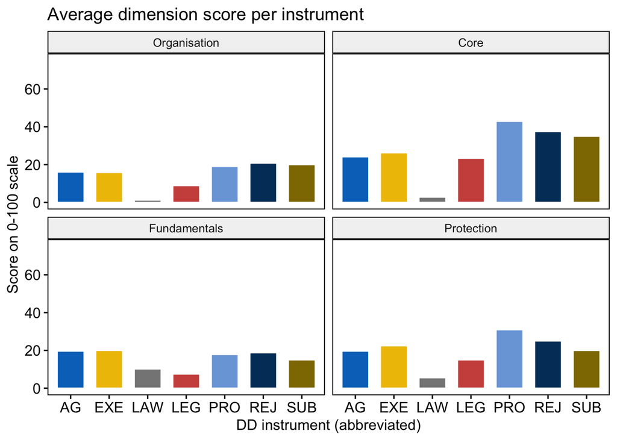

## Average per dimension for each instrument (showing all data points)

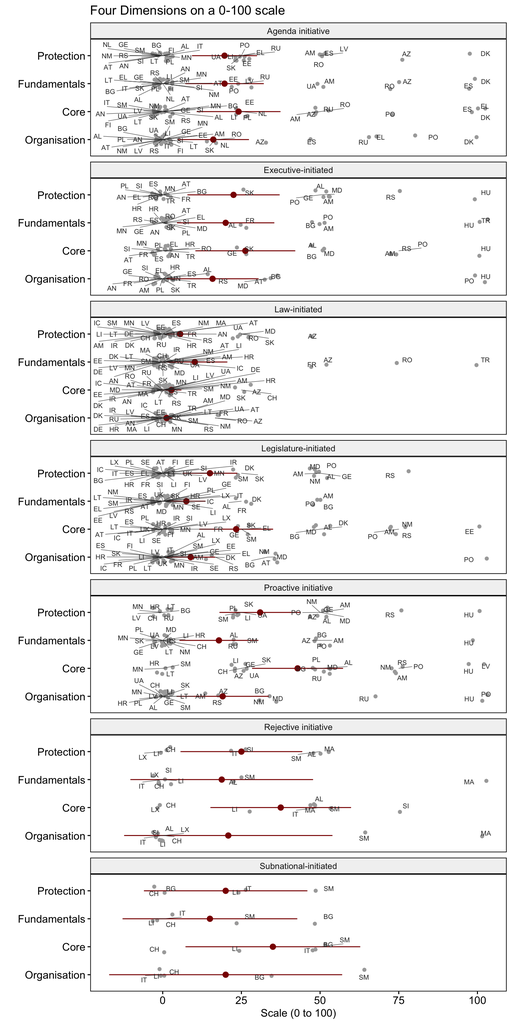